# Introdution

Businesses in the hospitality industry, such as hotels, rely heavily on customer feedback and popularity to attract and retain customers. However, even popular hotels may have flaws that can negatively impact their reputation and revenue. Reviews provide valuable insights for both businesses and potential customers, as they help to minimize risk by providing information about the pros and cons of a particular hotel.

# Aims and Objectives

# Data

### About the data

The data overall brings alot of information that can be used to explore interesting facts and performancees of the hotel.vThe positive aspect of the dataset is its extensive coverage of a period of more than 5 years, including a large number of ratings. This level of detail enhances the credibility of our conclusions and allows for the application of natural language processing (NLP) algorithms and sentiment analysis. Additionally, the data includes sufficient information for statistical analysis. However, some of the columns may not be relevant for our purposes and the volume of reviews may pose a challenge for sentiment analysis.

## Importing Libraries

Dependencies I installed the libraries for sentiment analysis and NLP

```python
#%pip install torch
#%pip install transformers
#%pip install wordcloud
```

libraries

```python
import os
import pandas as pd
import numpy as np
import matplotlib.pyplot as plt
import seaborn as sns
import datetime
import nltk
import string
import re

nltk.download('vader_lexicon')
from collections import Counter
from nltk.tag import pos_tag
from nltk.sentiment import SentimentIntensityAnalyzer
from tqdm.notebook import tqdm
from nltk.corpus import stopwords
from nltk.stem import WordNetLemmatizer
from nltk.stem import PorterStemmer
from wordcloud import WordCloud


import transformers
from transformers import pipeline
import torch
plt.style.use('ggplot')

nltk.download('punkt')
nltk.download('stopwords')
nltk.download('averaged_perceptron_tagger')
nltk.download('maxent_ne_chunker')
nltk.download('words')
nltk.download('wordnet')
nltk.download('omw-1.4')
```

```
True
```

### Read Data

```python
#creates a panda df by reading the data in csv
raw_df = pd.read_csv('HotelReviews.csv', encoding='latin-1')
```

Lets check the data to understand the dataset

```python
raw_df.head()
```

|  | user_id | contributions | date_of_stay | ratings | title | content |
| --- | --- | --- | --- | --- | --- | --- |
| 0 | 1 | 0 | 2022/8 | 5 | Great stay | Whole team was great and service 10/10. Receiv... |
| 1 | 2 | 81 | 2022/7 | 5 | MBS a luxurious destination | We are a family of 6 ( my 85 yearold father, 7... |
| 2 | 3 | 6 | 2022/8 | 5 | MBS truly understands their clients! | Throughout my stay, I felt that this establish... |
| 3 | 3 | 13 | 2016/3 | 4 | Wonderful Hotel but the service isn't really e... | I would say the architect of this hotel is fas... |
| 4 | 4 | 205 | 2022/10 | 5 | Amazing hotel | Amazing hotel, the check-in staff member was e... |

```python
#look for rows and columns
raw_df.shape
```

```
(10232, 6)
```

```python
raw_df.columns
```

```
Index(['user_id', 'contributions', 'date_of_stay', 'ratings', 'title',
       'content'],
      dtype='object')
```

```python
#basic initial analysis
raw_df.describe()
```

|  | user_id | contributions | ratings |
| --- | --- | --- | --- |
| count | 10232.000000 | 10232.000000 | 10232.000000 |
| mean | 4805.815383 | 175.248632 | 4.341869 |
| std | 2832.171176 | 1040.491601 | 1.002789 |
| min | 1.000000 | 0.000000 | 1.000000 |
| 25% | 2344.750000 | 15.000000 | 4.000000 |
| 50% | 4763.500000 | 44.000000 | 5.000000 |
| 75% | 7254.250000 | 121.000000 | 5.000000 |
| max | 9782.000000 | 64280.000000 | 5.000000 |

The code above shows average rating of all the reviews is 4.3

# Clean / Preprocess Data

As the column we are going to use for the processing is the content column. This column holds all the user feedback. This data needs some cleaning and processing as the data would have unneccesary information and characters that wont be usefull for us. The cleaning involves removig null values, but the preprocessing part involves:

- Remove Stop Words
- Remove non-alphabetic characters
- Make all letters Lowercase

##### Remove Null Values

To start , Lets clean rows that have any null values. This will help us to avoid any program errors and will increase credibility of results.

```python
df = raw_df
df = df.dropna()
```

```python
# check the updated df
df.shape
```

```
(9917, 6)
```

The results show that we skipped some of the rows in the dataset that were null

## Preprocess Reviews

#### Remove Punctuation Marks

It might be beneficial to remove punctuation marks from the review text as they may potentially impact the operation of certain sentiment analysis algorithms.

```python
def remove_punct(revText):
    #creats a translator table
    translator = str.maketrans('', '', string.punctuation)
    cleanText = revText.translate(translator)
    return cleanText
```

```python
#creates a df cleanReviews that is the processed column
df['cleanReviews'] = df['content'].apply(remove_punct)
```

### Remove Stop Words

Stopwords, which are words that do not significantly contribute to the meaning of a sentence (e.g. "a," "an," and "the"), may be removed from the review text to potentially enhance the accuracy of the sentiment analysis model.

```python
#To remove stopwords from df, we use the apply() method and a lambda function that filters out stopwords.
stopWords = set(stopwords.words('english'))
df['cleanReviews'] = df['cleanReviews'].apply(lambda x: ' '.join([word for word in x.split() if word not in stopWords]))
```

### Remove non-alphabetic characters

It may be advisable to remove numbers or special characters from the reviews as they can distract the sentiment analysis model from focusing on the words themselves. This may help to improve the model's performance.

```python
df['cleanReviews'] = df['cleanReviews'].apply(lambda x: re.sub('[^a-zA-Z ]', '', x))
```

### Make all letters Lowercase

Converting all the letters in the review text to lowercase can assist in the normalization of the text and facilitate the treatment of words like "power" and "Power" as equivalent by the model.

```python
df['cleanReviews'] = df['cleanReviews'].str.lower()
```

```python
df.head(5)
```

|  | user_id | contributions | date_of_stay | ratings | title | content | cleanReviews |
| --- | --- | --- | --- | --- | --- | --- | --- |
| 0 | 1 | 0 | 2022/8 | 5 | Great stay | Whole team was great and service 10/10. Receiv... | whole team great service received everything ... |
| 1 | 2 | 81 | 2022/7 | 5 | MBS a luxurious destination | We are a family of 6 ( my 85 yearold father, 7... | we family yearold father year old mother si... |
| 2 | 3 | 6 | 2022/8 | 5 | MBS truly understands their clients! | Throughout my stay, I felt that this establish... | throughout stay i felt establishment excelled ... |
| 3 | 3 | 13 | 2016/3 | 4 | Wonderful Hotel but the service isn't really e... | I would say the architect of this hotel is fas... | i would say architect hotel fascinating super ... |
| 4 | 4 | 205 | 2022/10 | 5 | Amazing hotel | Amazing hotel, the check-in staff member was e... | amazing hotel checkin staff member exceptional... |

As seen , we now have a column named cleanReviews with processed data that will be used for NLP and Sentiment Analysis

# EDA

Now that we have processed the data that we had, we can start exploring the data. To start with, lets plot the ratings of the user reviews in a bar graph to see if the hotel is liked generally.

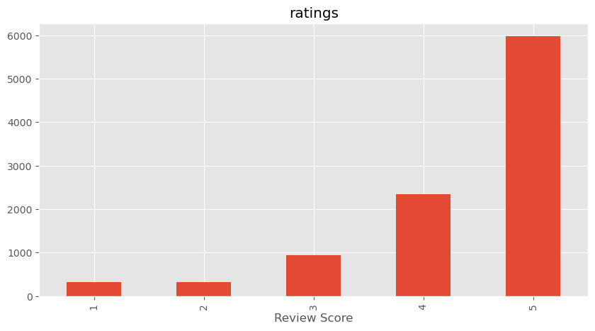

```python
ratingsplot = df['ratings'].value_counts().sort_index().plot(kind='bar',title='ratings', figsize=(10,5))
ratingsplot.set_xlabel('Review Score')
plt.show()
```

The bar graph above shows that the hotel has a good reputation as most of the people have rated it 5. Lets see according to the reviews, how many people have stayed in the hotel over the years. To do this, we have the column date_of_stay. This column is in format year/month. We want to see number of stays every year. We have to create another dataframe with values of years only.

```python
# creates a df named date
df["date"] = pd.to_datetime(df["date_of_stay"], errors="coerce")

# Creates a column year in the df
df["year"] = None

# Iterate over the rows in the "date" column
for index, row in df.iterrows():
    # Checks date value is a string
    if isinstance(row["date_of_stay"], str):
        # Extract year from date
        year = datetime.datetime.strptime(row["date_of_stay"], "%Y/%d").strftime("%Y")
        # Assign year to "year" column
        df.loc[index, "year"] = year
```

#### Plotting Bar Graph

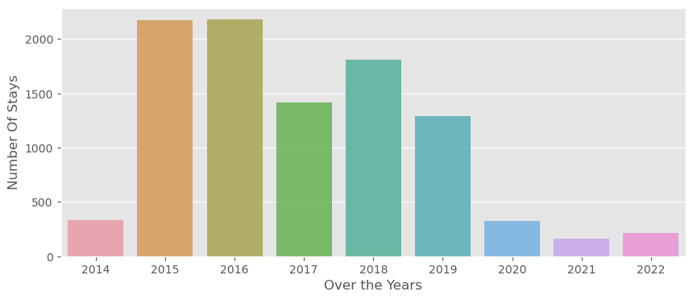

```python
stay_eachY = df['year'].value_counts()
#sorts the years in ascending order
stay_eachY  = stay_eachY .sort_index()
#plots the data on a bar graph
plt.figure(figsize=(10,4))
sns.barplot(x=stay_eachY .index, y=stay_eachY .values, alpha=0.8)
plt.ylabel("Number Of Stays")
plt.xlabel("Over the Years")
plt.show()
```

#### Plotting a line graph

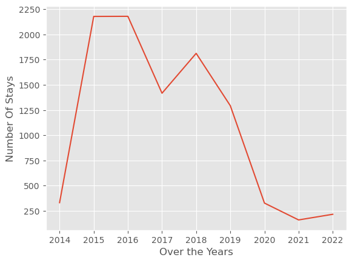

```python
stay_eachY.plot(kind="line")
plt.ylabel("Number Of Stays")
plt.xlabel("Over the Years")
plt.show()
```

The above graphs show that how the number of stays according to the reviews vary accros the years. We can se that the user feedback was highest in 2015 and 2016. Even though it does not evidenty represent number of people who stayed at this hotel every year. In addition the amount of user feedback can vary due to various reasons, but if we consider that every year there is a percentage of organic user feedback. In that case user reviews stayed above 1000 reviews. However, after 2019 they fell below 500. This has something to do with covid-19 effect. As it is evident from the sudden crash in the line graph and then it stays below for next three years.

Next lets see how consistent the average review ratings have been in the following years. With the best performing year and the worst rated year in the shadow of user feedback.

```python
ratingsMean = df.groupby('year')['ratings'].mean()
print(ratingsMean)
```

```
year
2014    4.469880
2015    4.309917
2016    4.293713
2017    4.362738
2018    4.348234
2019    4.385924
2020    4.350610
2021    4.409938
2022    4.451613
Name: ratings, dtype: float64
```

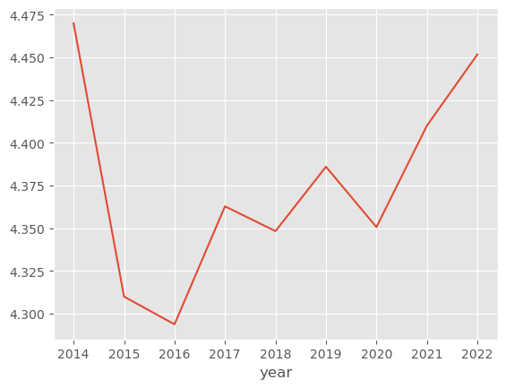

```python
ratingsMean.plot()
plt.show()
```

The graph above shows that the best performing year of the hotel was 2014 and the worst was in 2016. Using these results lets compare this graph with the number of stays graph to see if this somehow relates. The assumption here is to see if the user ratings got affected by the increase in number of stays. In addition to see if the hotel has been consistent.

### EDA Findings

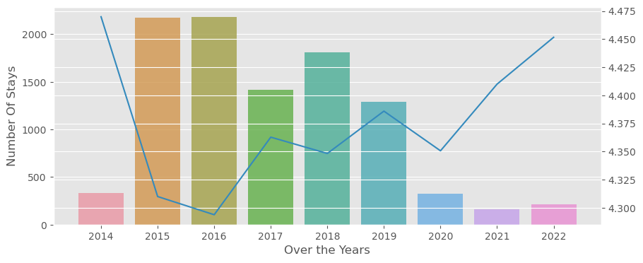

```python
# Plotting the bar graph
plt.figure(figsize=(10,4))
sns.barplot(x=stay_eachY.index, y=stay_eachY.values, alpha=0.8)

# title and labels
plt.ylabel("Number Of Stays")
plt.xlabel("Over the Years")

# y-axis on the right side of the plot for ratings
ax2 = plt.gca().twinx()

# Plot the line graph on the second y-axis
ratingsMean.plot(ax=ax2, color='C1')

# Show the plot
plt.show()
```

# NLP

Natural Language Processing (NLP) focuses on making it possible for computers to read, understand, and generate human language. It is important because it enables computers to process and analyze large amounts of natural language data, which is critical for tasks such as automatic translation, sentiment analysis, and topic modeling.  
In this study, we will be using NLP techniques to process and analyze a dataset of reviews in order to explore various aspects of the text. By applying NLP techniques such as text preprocessing, feature extraction, and machine learning algorithms, we will be able to gain insights and draw conclusions from the review data. Our goal is to see if we are able to list some popular features and things about the hotel that people mentioned in the comments.  
In the folllowing part we start by taking the pre processed reviews and explore them to find something interesting from the reviews. To start, lets join all the reviews and tokenize all the words to search and process.

```python
all_reviews = " ".join(df.cleanReviews)
words = nltk.word_tokenize(all_reviews)
#
words_BOM = nltk.Text(words)
```

```python
#length of words tokenized
len(words_BOM)
```

```
753935
```

We can also use nltk count to see how many time people have talked about some thing, and also use nltk similar to find words that have been mentioned similar to the word we are looking for.

```python
#number of times people mentioned pool
words_BOM.count('pool')
```

```
13522
```

```python
#find words that have occured in a similar way
words_BOM.similar("casino")
```

```
hotel pool room the restaurants rooms great huge singapore mall
amazing view stay big good views nice breakfast bathroom staff
```

Now lets see the data using a word cloud. Word Clouds are a popular technique to display some words that are most used in the data set, this allows us to understand the sentiment and the features inside the data.

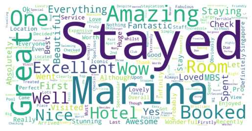

```python
#generate a word cloud based on the text data in the content column
text = " ".join(cat.split()[0] for cat in df.content)
#
word_cloud = WordCloud(width = 2000, height = 1000, collocations = False, background_color = 'white').generate(text)
plt.imshow(word_cloud, interpolation='bilinear')
plt.axis("off")
plt.show()
```

By looking at the above data, we can see the words that float on the top, from which there are words that give us a overwiew of the sentiments of user reviews. We can see the complements and other positive words. Even though this technique provides us with an overview of the data, it does not provide all the features and things that are talked about in the reviews. By features we mean popular features of the hotel such as coffee or casino. Therefore, we should dig in further to find some things that people thought were worth mentioning. To do this, we use nltk to find the frequency of most repeated words.

```python
#using nltk to find most repeated words in the
most_freqWords = nltk.FreqDist(words_BOM)
#find the first 50 most common words
most_freqWords.most_common(20)
```

```
[('the', 16025),
 ('hotel', 15506),
 ('i', 15043),
 ('pool', 13522),
 ('room', 12801),
 ('we', 7712),
 ('view', 7302),
 ('stay', 5903),
 ('bay', 5670),
 ('singapore', 5229),
 ('great', 4941),
 ('one', 4909),
 ('service', 4537),
 ('staff', 4409),
 ('amazing', 4352),
 ('night', 4027),
 ('infinity', 4019),
 ('time', 3691),
 ('would', 3654),
 ('check', 3618)]
```

The code above shows the 20 most repeated words in the reviews. The words include some words like 'great' and 'amazing' that represent sentiments of people . Another way to see things that are most talked about is by using nltk collocations. This prints the most repeated pair of words. This will also help us to understand the context of the things a little.

```python
words_BOM.collocations()
```

```
marina bay; infinity pool; bay sands; gardens bay; light show;
swimming pool; one night; shopping mall; city view; afternoon tea;
roof top; bucket list; front desk; food court; come back; club room;
canap ues; observation deck; highly recommend; shopping centre
```

As seen above the pairs listed have more meaningful words. We can see things people have mentioned. Things that have been in talks about the hotel. Lets take this further and combine the results of collocations and frequency ,this will help us to explore what are the things that are most talked about.  
For this we can iterate on words_BOM and see the frequency of the word. We will use single words from the pairs extracted above. For example we will use "pool" for the search mothod instead of the pair as this will increase effiiency and credibility of the search without affecting our assumption.

```python
#creating a dictionary
wordCounts = {}
#iterate over the words to find in list
for word in ['pool', 'room', 'service','tea', 'view', 'mall', 'court', 'roof', '57th']:
    wordCounts[word] = words_BOM.count(word)
```

### NLP Findings

Now lets make a bar graph of the results that we have found to see which words most mentioned in the reviews.

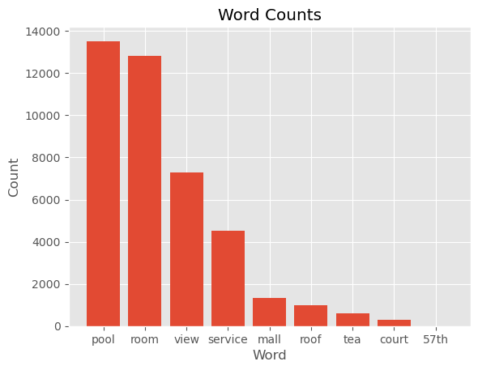

```python
# sort the amount of word counts
counts = sorted(wordCounts.values(), reverse=True)
words = [word for word, count in sorted(wordCounts.items(), key=lambda item: item[1], reverse=True)]
plt.bar(words, counts)
plt.title('Word Counts')
plt.xlabel('Word')
plt.ylabel('Count')
plt.show()
```

From the results above we can see that alot of reviews talk about the pool of the hotel. This shows popularity of their infinity pool. This also allows the visitors to keep this in their bucket list to visit the pool. Most people also talk about the view and rooms of the hotel. The mall and the roof top are some other features about the hotel that are most talked about.

# Sentiment Analysis

Sentiment analysis is a natural language processing technique that aims to determine the sentiment or emotion behind a piece of text. It is commonly used to analyze customer reviews, social media posts, and other forms of online feedback to understand how people feel about a product, service, or brand.

By analyzing the sentiment of user reviews, you can gain valuable insights into the thoughts and feelings of your customers. This can help you identify trends and patterns in the reviews, and understand what your customers like and dislike about your product or service. It can also help you identify any negative sentiment that may be impacting your brand reputation, and take steps to address any issues that may arise.

For our sentiment Analysis , we used two models

##### Vader

VADER(Valence Aware Dictionary and Sentiment Reasoner) is a tool for analyzing the sentiment of social media text. It uses a set of rules and a pre-defined list of words to identify the sentiment of a text.

##### Roberta

RoBERTa(Robustly Optimized BERT Approach) is a language model created by Facebook that can be customized for specific tasks. It is based on transformers and uses a pre-trained model that can be modified with task-specific layers.

### Sort Dataset

First we will sort the data in descending order form. This will help us to use the recent values to perform sentiment analysis. As the data set is big and the sentiment analysis algorithm require alot of processing, We will use first 1000 values only.

```python
#create new df for sorted values
df_Sorted = df.sort_values(by='year', ascending=False)
```

### Lemmatize Words

Lemmatization is a technique that can be used to reduce words to their base form, which is known as a lemma. This technique is often used in natural language processing tasks as a preprocessing step to improve the performance of machine learning models. By reducing inflected forms of a word to a common base form, lemmatization can help the model better understand the context and sentiment of the text. For example, lemmatization would convert the words "running," "ran," and "runs" to the base form "run." This can help the model more accurately analyze the sentiment of a review or other piece of text.

```python
lemmatizer = WordNetLemmatizer()
df_Sorted['cleanReviews'] = df_Sorted['cleanReviews'].apply(lambda x: ' '.join([lemmatizer.lemmatize(word) for word in nltk.word_tokenize(x)]))
```

```python
df_Sorted.head(5)
```

|  | user_id | contributions | date_of_stay | ratings | title | content | cleanReviews | date | year |
| --- | --- | --- | --- | --- | --- | --- | --- | --- | --- |
| 0 | 1 | 0 | 2022/8 | 5 | Great stay | Whole team was great and service 10/10. Receiv... | whole team great service received everything i... | 2022-08-01 | 2022 |
| 176 | 146 | 2733 | 2022/5 | 4 | Infinity Pool is Amazing | My wife and I stayed at the Marina Bay Sands H... | my wife i stayed marina bay sand hotel three n... | 2022-05-01 | 2022 |
| 163 | 133 | 5 | 2022/5 | 5 | Awesome | Lots to say, firstly I would like to thank all... | lot say firstly i would like thank staff check... | 2022-05-01 | 2022 |
| 164 | 134 | 10 | 2022/5 | 5 | Greatest Ezperience overall | I would like to thank all staff from check in ... | i would like thank staff check reception house... | 2022-05-01 | 2022 |
| 166 | 136 | 67 | 2022/5 | 3 | Great view, but train station feeling | Stayed in many 5 Star Hotels in Singapore over... | stayed many star hotel singapore year the mb c... | 2022-05-01 | 2022 |

```python
df_Sorted.columns
```

```
Index(['user_id', 'contributions', 'date_of_stay', 'ratings', 'title',
       'content', 'cleanReviews', 'date', 'year'],
      dtype='object')
```

```python
df_Sorted.drop(columns=['contributions', 'date_of_stay', 'title','content', 'date', 'year'], axis=1, inplace=True)
```

```python
df_Sorted.columns
```

```
Index(['user_id', 'ratings', 'cleanReviews'], dtype='object')
```

## Vader Sentiment Analysis

```python
senti_Analyze = SentimentIntensityAnalyzer()
#Sample Test
senti_Analyze.polarity_scores('I am so angry i will kill you')
```

```
{'neg': 0.681, 'neu': 0.319, 'pos': 0.0, 'compound': -0.861}
```

As seen above the sentence provided has a very negative sentiment, and it contains no positive sentiment. Due to the high negativity of the sentence the compound score is also in negative.

- The term 'neg' refers to a negative sentiment score that indocates that the model identified a negative emotion or sentiment
- The term 'neu' refers to a neutral sentiment score that indicates that the model thinks its not not strongly negative or positive
- The term 'pos' refers to a positive sentiment score that indocates that the model identified a positive emotion or sentiment
- The compound score combines the positive, negative, and neutral scores into a single score that ranges from -1 to 1. A score of -1 indicates a very negative sentiment, a score of 0 indicates a neutral sentiment, and a score of 1 indicates a very positive sentiment.

```python
df_Sorted.cleanReviews[60]
```

```
'i stayed time loved first visit good time the hotel great lovely room pool wonderful unfortunately book pool morning booking get poolside man duty kindly let u pool sky bar lovely refused entry leaving airport pm told table booked spite empty we given bar stool seat restaurant remained empty till l…
```

The comment here is a mix sentiment of negative and positive, the user compliments the plae in the start but then also talks about how things did not went well this time.Overall the comment tends to be more neutral.

```python
senti_Analyze.polarity_scores(df_Sorted.cleanReviews[60])
```

```
{'neg': 0.138, 'neu': 0.627, 'pos': 0.236, 'compound': 0.945}
```

#### Analyze Polarity Score for complete dataset

Now that we can see that we can find the polarity scores for a single review, we can now iterate through all the dataset and find sentment scores for all reviews.Then i the next cell we merge the findings of the scores to the datarame for ffurther analysis.

```python
df_1000 = df_Sorted.head(1000)
#Now we analyze the data set
results = {}
for i, r in tqdm(df_1000.iterrows(), total = len(df_1000)):
    review = r['cleanReviews']
    userId = r['user_id']
    results[userId] = senti_Analyze.polarity_scores(review)
```

```python
sent_result = pd.DataFrame(results).T
sent_result = sent_result.reset_index().rename(columns = {'index': 'id'})
sent_result = sent_result.merge(df_Sorted, how='left', left_index=True, right_index=True)
sent_result
```

|  | id | neg | neu | pos | compound | user_id | ratings | cleanReviews |
| --- | --- | --- | --- | --- | --- | --- | --- | --- |
| 0 | 1 | 0.000 | 0.492 | 0.508 | 0.9382 | 1.0 | 5.0 | whole team great service received everything i... |
| 1 | 146 | 0.060 | 0.589 | 0.352 | 0.9959 | 2.0 | 5.0 | we family yearold father year old mother sisin... |
| 2 | 133 | 0.000 | 0.509 | 0.491 | 0.9969 | 3.0 | 5.0 | throughout stay i felt establishment excelled ... |
| 3 | 134 | 0.000 | 0.575 | 0.425 | 0.9552 | 3.0 | 4.0 | i would say architect hotel fascinating super ... |
| 4 | 136 | 0.065 | 0.504 | 0.431 | 0.9878 | 4.0 | 5.0 | amazing hotel checkin staff member exceptional... |
| ... | ... | ... | ... | ... | ... | ... | ... | ... |
| 982 | 1478 | 0.000 | 0.697 | 0.303 | 0.9715 | 885.0 | 5.0 | what i say place thats already said k review f... |
| 983 | 1492 | 0.065 | 0.836 | 0.099 | 0.3182 | 886.0 | 5.0 | where start leviathan hotel three tower around... |
| 984 | 1503 | 0.030 | 0.814 | 0.155 | 0.9630 | 887.0 | 3.0 | we werent impressed stay the welcome front des... |
| 985 | 1501 | 0.093 | 0.769 | 0.139 | 0.7139 | 888.0 | 5.0 | you get better view singapore one marina bay s... |
| 986 | 1499 | 0.028 | 0.788 | 0.184 | 0.8931 | 889.0 | 5.0 | this first time singapore we decided stay mari... |

987 rows × 8 columns

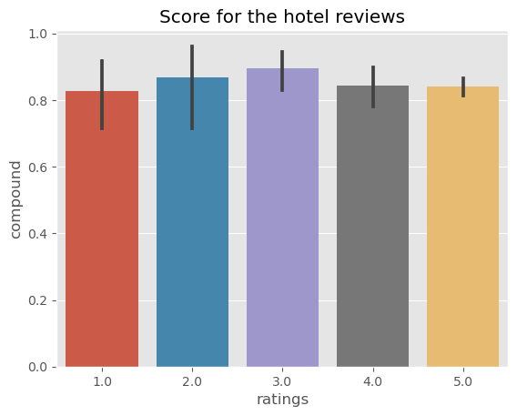

```python
#plot vader analysis results
ax = sns.barplot(data = sent_result, x = 'ratings', y = 'compound')
ax.set_title('Score for the hotel reviews')
plt.show()
```

Now from the barplot here we can see that the model did not find any negative compound in the reviews. This is a very good result for the hotel as the reviews are not strongly negative. This can also mean that the user feedback has been inclined towards positivity as the compound score stay high. However, the model cannot be highly accurate and therefore the analysis can vary.

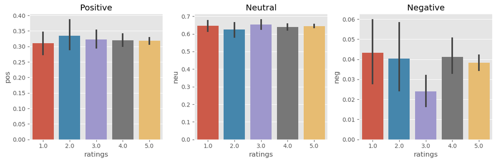

```python
fig, axs = plt.subplots(1, 3, figsize = (12,4))
axs[0].set_title('Positive')
sns.barplot(data = sent_result, x = 'ratings', y = 'pos' , ax = axs[0])
axs[1].set_title('Neutral')
sns.barplot(data = sent_result, x = 'ratings', y = 'neu' , ax =axs[1])
axs[2].set_title('Negative')
sns.barplot(data = sent_result, x = 'ratings', y = 'neg' , ax =axs[2])
plt.tight_layout()
plt.show()
```

The bar graphs above presents three sides.

# Trying the roberta model

The vader model has shown positive resuts , However the results may vary using another model. As the sentiments are also dependent on the context of the text , it is important that we verify the findings by using another model. This will allow us to explore how the models work differently and whether the findings benefit us in some way.

```python
from transformers import AutoTokenizer
from transformers import AutoModelForSequenceClassification
from scipy.special import softmax
import torch
```

```python
Model = f"cardiffnlp/twitter-roberta-base-sentiment"
tokenizer = AutoTokenizer.from_pretrained(Model)
Model2 = AutoModelForSequenceClassification.from_pretrained(Model)
```

### Comparing a Sample (Vader vs Roberta)

As we did sentiment analysis on a sample review earlier. Lets take the same review and compare the polarity scores.

```python
# Vader Result
print(df_Sorted.cleanReviews[60])
senti_Analyze.polarity_scores(df_Sorted.cleanReviews[60])
```

```
i stayed time loved first visit good time the hotel great lovely room pool wonderful unfortunately book pool morning booking get poolside man duty kindly let u pool sky bar lovely refused entry leaving airport pm told table booked spite empty we given bar stool seat restaurant remained empty till le…
```

```
{'neg': 0.138, 'neu': 0.627, 'pos': 0.236, 'compound': 0.945}
```

```python
# Roberta Result
encoded_text = tokenizer(df_Sorted.cleanReviews[60], return_tensors = 'pt')
output = Model2(**encoded_text)
scores = output[0][0].detach().numpy()
scores = softmax(scores)
scores_dict = {
    'roberta_neg' : scores[0],
    'roberta_neu' : scores[1],
    'roberta_pos' : scores[2]
}
print(scores_dict)
```

```
{'roberta_neg': 0.07004, 'roberta_neu': 0.18306987, 'roberta_pos': 0.7468902}
```

The resuts do have a difference, as according to the roberta model, the review is more positive than netral. The results cannot be used to differentiate between the models, to see the differences more clearly we have to perform the sentiment analysis on the whole data set like we did for the Vader Model.

We start by creating a function that we can use to find the polarity scores. Then we can iterate through the dataset like we did ealier.

```python
#function tokenizes and stores the polarity scores in a dictionary
def roberta_polarityScores(example):
    encoded_text = tokenizer(example, return_tensors = 'pt')
    output = Model2(**encoded_text)
    scores = output[0][0].detach().numpy()
    scores = softmax(scores)
    scores_dict = {
        'roberta_neg' : scores[0],
        'roberta_neu' : scores[1],
        'roberta_pos' : scores[2]
    }
    #returns polarity scores
    return scores_dict
```

```python
#create a dataframe of 1000 rows
rob_df_1000 = df_Sorted.head(1000)
#store the scores
results = {}
for i, r in tqdm(rob_df_1000.iterrows(), total = len(rob_df_1000)):
    try:
        review = r['cleanReviews']
        userId = r['user_id']
        vader_Results = senti_Analyze.polarity_scores(review)
        new_vader_Results = {}
        for key, value in vader_Results.items():
            new_vader_Results[f"vader_{key}"] = value

        roberta_Results = roberta_polarityScores(review)
        new_vader_Results.update(roberta_Results)
        results[userId] = new_vader_Results
    except RuntimeError:
        print(f'error for id{userId}')
```

```
error for id195
error for id202
error for id261
error for id521
error for id391
```

### Combining results in dataframe

```python
df_res = pd.DataFrame(results).T
df_res = df_res.reset_index().rename(columns = {'index': 'id'})
df_res = df_res.merge(rob_df_1000, how='left', left_index=True, right_index=True)
```

```python
df_res.head(20)
```

|  | id | vader_neg | vader_neu | vader_pos | vader_compound | roberta_neg | roberta_neu | roberta_pos | user_id | ratings | cleanReviews |
| --- | --- | --- | --- | --- | --- | --- | --- | --- | --- | --- | --- |
| 0 | 1 | 0.000 | 0.492 | 0.508 | 0.9382 | 0.003601 | 0.027720 | 0.968679 | 1.0 | 5.0 | whole team great service received everything i... |
| 1 | 146 | 0.060 | 0.589 | 0.352 | 0.9959 | 0.011362 | 0.274760 | 0.713878 | 2.0 | 5.0 | we family yearold father year old mother sisin... |
| 2 | 133 | 0.000 | 0.509 | 0.491 | 0.9969 | 0.002456 | 0.019282 | 0.978262 | 3.0 | 5.0 | throughout stay i felt establishment excelled ... |
| 3 | 134 | 0.000 | 0.575 | 0.425 | 0.9552 | 0.002674 | 0.029865 | 0.967462 | NaN | NaN | NaN |
| 4 | 136 | 0.065 | 0.504 | 0.431 | 0.9878 | 0.015948 | 0.087992 | 0.896059 | 4.0 | 5.0 | amazing hotel checkin staff member exceptional... |
| 5 | 137 | 0.000 | 0.521 | 0.479 | 0.9769 | 0.001795 | 0.012542 | 0.985663 | 5.0 | 2.0 | you go casino infinity pool attractive the inf... |
| 6 | 138 | 0.188 | 0.812 | 0.000 | -0.6980 | 0.930785 | 0.062081 | 0.007135 | 6.0 | 5.0 | clearly beautiful place iconic one overrated r... |
| 7 | 139 | 0.031 | 0.712 | 0.257 | 0.9678 | 0.005651 | 0.060920 | 0.933429 | 7.0 | 5.0 | it first time singapore f i glad i chance stay... |
| 8 | 140 | 0.000 | 0.702 | 0.298 | 0.9325 | 0.004319 | 0.030806 | 0.964875 | 8.0 | 1.0 | stay sep sep hotel requested security deposit ... |
| 9 | 141 | 0.000 | 0.753 | 0.247 | 0.9873 | 0.011780 | 0.430404 | 0.557817 | 9.0 | 5.0 | marina bay sand must visit place anyone would ... |
| 10 | 142 | 0.000 | 0.706 | 0.294 | 0.8750 | 0.001748 | 0.016674 | 0.981577 | 10.0 | 5.0 | one best hotel singapore garden view open balc... |
| 11 | 143 | 0.016 | 0.705 | 0.279 | 0.9709 | 0.002865 | 0.038319 | 0.958815 | 11.0 | 5.0 | we stayed marina bay sand three night this hot... |
| 12 | 144 | 0.000 | 0.832 | 0.168 | 0.9806 | 0.003775 | 0.165038 | 0.831186 | 12.0 | 3.0 | we arrived singapore family beforehand arrived... |
| 13 | 145 | 0.000 | 0.633 | 0.367 | 0.9870 | 0.002120 | 0.019069 | 0.978810 | 13.0 | 5.0 | it enormous sprawling hotel checkin experience... |
| 14 | 147 | 0.020 | 0.550 | 0.430 | 0.9895 | 0.001972 | 0.016462 | 0.981566 | 13.0 | 5.0 | location brilliant service immaculate price hi... |
| 15 | 131 | 0.026 | 0.626 | 0.348 | 0.9803 | 0.006905 | 0.043444 | 0.949651 | 14.0 | 5.0 | we lovely time mb the service outstanding faci... |
| 16 | 148 | 0.000 | 0.674 | 0.326 | 0.9514 | 0.001463 | 0.028671 | 0.969866 | 15.0 | 5.0 | this nd time mb i great stay i would like say ... |
| 17 | 149 | 0.029 | 0.670 | 0.301 | 0.9577 | 0.024550 | 0.266355 | 0.709096 | 16.0 | 5.0 | this hotel deserves star sheer size our visit ... |
| 18 | 150 | 0.000 | 0.603 | 0.397 | 0.9643 | 0.003017 | 0.066516 | 0.930467 | NaN | NaN | NaN |
| 19 | 151 | 0.000 | 0.696 | 0.304 | 0.9854 | 0.002655 | 0.023425 | 0.973920 | NaN | NaN | NaN |

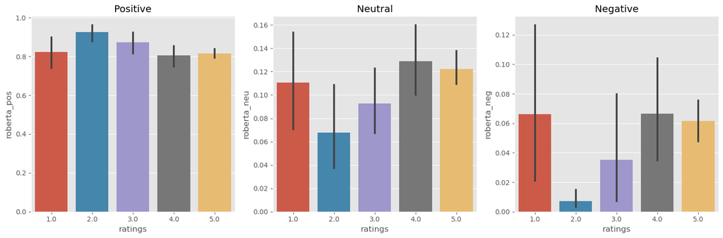

```python
fig, axes = plt.subplots(1, 3, figsize=(15, 5))
sns.barplot(data=df_res, x='ratings', y='roberta_pos', ax = axes[0])
sns.barplot(data=df_res, x='ratings', y='roberta_neu', ax = axes[1])
sns.barplot(data=df_res, x='ratings', y='roberta_neg', ax = axes[2])
axes[0].set_title('Positive')
axes[1].set_title('Neutral')
axes[2].set_title('Negative')
plt.tight_layout()
plt.show()
```

Now as seen by the results here, the positive graph shows consistency and is very similar to the vader model. The neutral grap however, showssome variations where the score varies in the middle ratings. The negative bar graoh somehow depicts a more closer result to our expectations where we see dip in neg scores, however this too does not support the sentiments confidently.

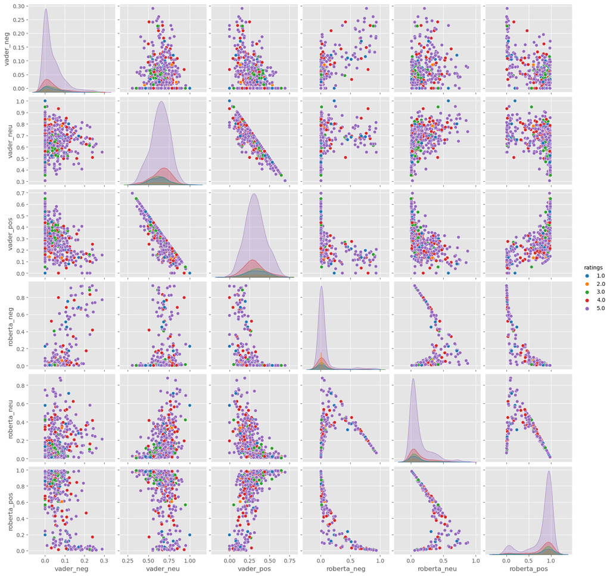

```python
sns.pairplot(data=df_res,
             vars= ['vader_neg', 'vader_neu', 'vader_pos','roberta_neg', 'roberta_neu', 'roberta_pos'],
            hue = 'ratings',
            palette= 'tab10')
plt.show()
```

The results here do show a better representation of both models. The five star reviews are in purple.  
Looking at the vader model we can see the positive reviews are slightly more on the right side, However the roberta model puts the positive reviews confidently on the right sideThe other graphs do display at some instances that the results might be corelated to each other. The one noticable thing in the results is that vader model seems to be less cofident in choosing the positivety of the sentiments regardless of the accuracy.

# Conclusion

## Datasets Used

```python
# Initial dataframe holding the data from csv
raw_df.shape
```

```
(10232, 6)
```

```python
#Data frame(Copy of raw_df) for processing
df.shape
```

```
(9917, 9)
```

```python
#processed data set
df.head(5)
```

|  | user_id | contributions | date_of_stay | ratings | title | content | cleanReviews | date | year |
| --- | --- | --- | --- | --- | --- | --- | --- | --- | --- |
| 0 | 1 | 0 | 2022/8 | 5 | Great stay | Whole team was great and service 10/10. Receiv... | whole team great service received everything ... | 2022-08-01 | 2022 |
| 1 | 2 | 81 | 2022/7 | 5 | MBS a luxurious destination | We are a family of 6 ( my 85 yearold father, 7... | we family yearold father year old mother si... | 2022-07-01 | 2022 |
| 2 | 3 | 6 | 2022/8 | 5 | MBS truly understands their clients! | Throughout my stay, I felt that this establish... | throughout stay i felt establishment excelled ... | 2022-08-01 | 2022 |
| 3 | 3 | 13 | 2016/3 | 4 | Wonderful Hotel but the service isn't really e... | I would say the architect of this hotel is fas... | i would say architect hotel fascinating super ... | 2016-03-01 | 2016 |
| 4 | 4 | 205 | 2022/10 | 5 | Amazing hotel | Amazing hotel, the check-in staff member was e... | amazing hotel checkin staff member exceptional... | 2022-10-01 | 2022 |

```python
#words_BOM contains tokenized words from all reviews
len(words_BOM)
```

[output not shown]

```python
#Sorted dataframe in descending years
df_Sorted.head(5)
```

|  | user_id | ratings | cleanReviews |
| --- | --- | --- | --- |
| 0 | 1 | 5 | whole team great service received everything i... |
| 176 | 146 | 4 | my wife i stayed marina bay sand hotel three n... |
| 163 | 133 | 5 | lot say firstly i would like thank staff check... |
| 164 | 134 | 5 | i would like thank staff check reception house... |
| 166 | 136 | 3 | stayed many star hotel singapore year the mb c... |

```python
#Data frame hold first 1000 values for vader analysis
df_1000
```

|  | user_id | ratings | cleanReviews |
| --- | --- | --- | --- |
| 0 | 1 | 5 | whole team great service received everything i... |
| 176 | 146 | 4 | my wife i stayed marina bay sand hotel three n... |
| 163 | 133 | 5 | lot say firstly i would like thank staff check... |
| 164 | 134 | 5 | i would like thank staff check reception house... |
| 166 | 136 | 3 | stayed many star hotel singapore year the mb c... |
| ... | ... | ... | ... |
| 1624 | 1478 | 5 | the hotel quite impresive observation deck lev... |
| 1639 | 1492 | 4 | lovely walk along promenade night backdrop mar... |
| 1650 | 1503 | 5 | i read unfavourable review almost made change ... |
| 1648 | 1501 | 3 | i picked hotel place stay singapore it icon si... |
| 1646 | 1499 | 5 | my adult son i stayed night week ago i can not... |

1000 rows × 3 columns

```python
#Data frame hold first 1000 values for roberta analysis
rob_df_1000
```

|  | user_id | ratings | cleanReviews |
| --- | --- | --- | --- |
| 0 | 1 | 5 | whole team great service received everything i... |
| 176 | 146 | 4 | my wife i stayed marina bay sand hotel three n... |
| 163 | 133 | 5 | lot say firstly i would like thank staff check... |
| 164 | 134 | 5 | i would like thank staff check reception house... |
| 166 | 136 | 3 | stayed many star hotel singapore year the mb c... |
| ... | ... | ... | ... |
| 1624 | 1478 | 5 | the hotel quite impresive observation deck lev... |
| 1639 | 1492 | 4 | lovely walk along promenade night backdrop mar... |
| 1650 | 1503 | 5 | i read unfavourable review almost made change ... |
| 1648 | 1501 | 3 | i picked hotel place stay singapore it icon si... |
| 1646 | 1499 | 5 | my adult son i stayed night week ago i can not... |

1000 rows × 3 columns

## References:

1. Dataset is taken from [Kaggle](https://www.kaggle.com/datasets/lucashkliu/marina-bay-sands-hotel-reviews-on-tripadvisor)
2. sentiment analysis: [Python Sentiment Analysis, Rob Mulla, May 5, 2022](https://www.youtube.com/watch?v=QpzMWQvxXWk)
3. word frequency and processiong: [Beginner NLP Data Science Project with Python, Aver Smith, September 1, 2022](https://www.youtube.com/watch?v=sZNNdJro_sw)
4. Cleaning up the data [A Quick Guide to Text Cleaning Using the nltk Library, Yash Joshi, November 27, 2020](https://www.analyticsvidhya.com/blog/2020/11/text-cleaning-nltk-library/)
5. Creating a [World Cloud](https://www.geeksforgeeks.org/generating-word-cloud-python/)
6. Searh and [Frequency of words](https://www.pythonprogramming.in/find-frequency-of-each-word-from-a-text-file-using-nltk.html)